# Packet 1: Relationships among scales

Last updated 2018-04-05

# Correlation matrix

```
Setting row names on a tibble is deprecated.
```

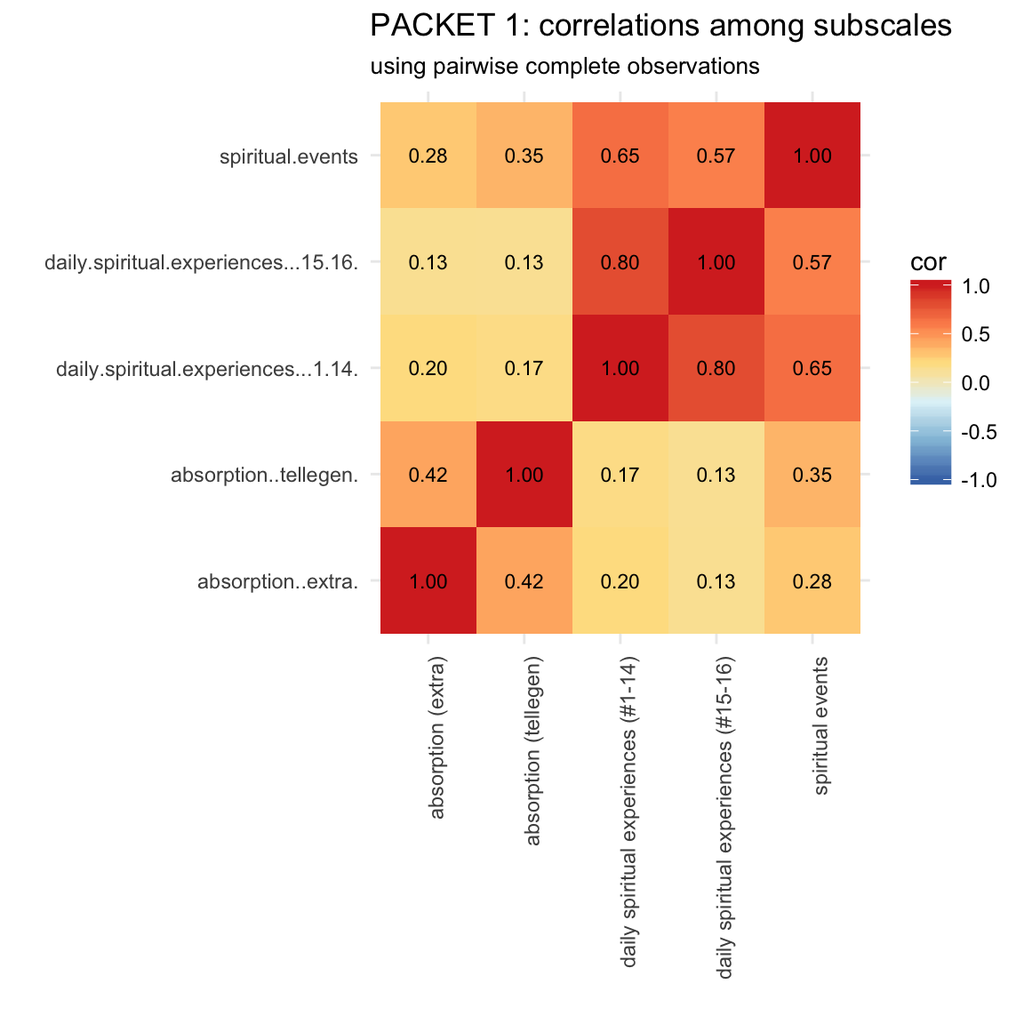

From this, we see that several of the scales included in Packet 1 were positively correlated with each other. Less surprisingly, the spiritual events scales were correlated with each other, and the absorption-ish scales were correlated with each other. But we also see some intriguing correlations between these two groups. Let’s check these relationships out in more detail!

# Absorption and spiritual events

## …as indexed by the “Spiritual events” scale (Luhrmann)

Let’s look at relationships between absorption & spiritual events across individual participants, but separating out by site. Tanya’s strong prediction would be that higher absorption (as captured by the Tellegen scale) would be correlated with more spiritual events (as indxed by the Luhrmann scale).

Here’s a test for the overall correlation:

```
    Pearson's product-moment correlation

data:  absorption (tellegen) and spiritual events
t = 8.5542, df = 519, p-value < 2.2e-16
alternative hypothesis: true correlation is not equal to 0
95 percent confidence interval:
 0.2738919 0.4246064
sample estimates:
      cor
0.3515247
```

Looks like this prediction is born out by the data! Absorption was significantly positively correlated with reported spiritual events ($r$ = 0.35, $p$ = <0.001), accounting for approximately 12% of the variance in reported spirtual events.

Now let’s take a look at what’s going on in each site with a regression analysis:

|  | b | se | t | p |
| --- | --- | --- | --- | --- |
| baserate (overall) | 17.51 | 0.51 | 34.2 | <0.001 |
| baserate (ghana vs. overall) | 16.14 | 1.04 | 15.4 | <0.001 |
| baserate (thailand vs. overall) | -6.17 | 0.97 | -6.3 | <0.001 |
| baserate (china vs. overall) | -10.81 | 1.01 | -10.7 | <0.001 |
| baserate (vanuatu vs. overall) | 5.00 | 1.11 | 4.5 | <0.001 |
| absorption (overall) | 0.96 | 0.08 | 11.5 | <0.001 |
| absorption (ghana vs. overall) | 0.45 | 0.15 | 3.0 | 0.003 |
| absorption (thailand vs. overall) | -0.26 | 0.18 | -1.5 | 0.140 |
| absorption (china vs. overall) | -0.36 | 0.18 | -2.0 | 0.043 |
| absorption (vanuatu vs. overall) | 0.31 | 0.18 | 1.8 | 0.079 |

These results indicate that, as predicted, there was a significant positive relationship between absorption and reported spiritual events, collapsing across sites ($b$ = 0.96, $p$ = <0.001). The relationship between absorption and spiritual events was particularly strong among participants in Ghana ($b$ = 0.45, $p$ = 0.003), and (perhaps) weaker than average among participants in China ($b$ = -0.36, $p$ = 0.043).

Note also that there are overall differences in the baserates for reporting spiritual events: Participants in Ghana and Vanuatu generally reported more than average (Ghana: $b$ = 16.14, $p$ = <0.001; Vanuatu: $b$ = 5.00, $p$ = <0.001), while participants in Thailand and China generally reported fewer than average (Thailand: $b$ = -6.17, $p$ = <0.001; China: $b$ = -10.81, $p$ = <0.001).

Here’s a visualization of these relationships:

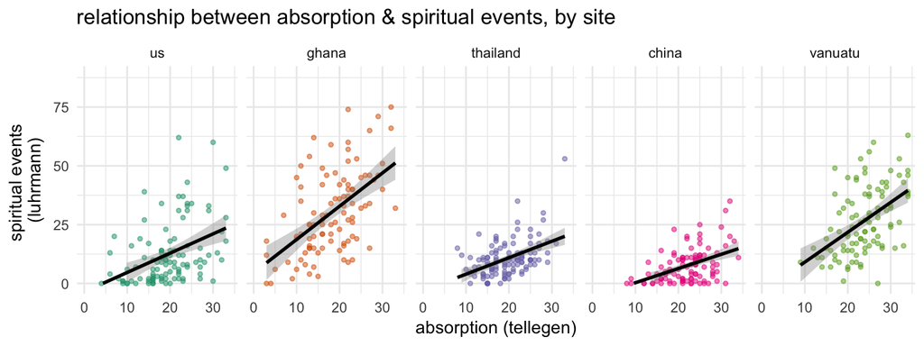

## …as indexed by the “Daily spiritual experiences” scale (Underwood & Teresi)

Let’s look at the same thing, except using Underwood & Teresi’s DSE scale. Again, Tanya’s strong prediction would be that higher absorption (as captured by the Tellegen scale) would be correlated with more spiritual events (as indxed by the Underwood & Teresi scale).

Here’s a test for the overall correlation:

```
    Pearson's product-moment correlation

data:  absorption (tellegen) and dse_total
t = 3.9379, df = 518, p-value = 9.345e-05
alternative hypothesis: true correlation is not equal to 0
95 percent confidence interval:
 0.08575824 0.25276810
sample estimates:
      cor
0.1704873
```

Again, looks like this prediction is born out by the data! Absorption was significantly positively correlated - albeit more weakly than above - with reported spiritual events ($r$ = 0.17, $p$ = <0.001), accounting for approximately 3% of the variance in reported spirtual events.

Now let’s take a look at what’s going on in each site with a regression analysis:

|  | b | se | t | p |
| --- | --- | --- | --- | --- |
| baserate (overall) | 37.37 | 0.59 | 63.78 | <0.001 |
| baserate (ghana vs. overall) | 17.08 | 1.19 | 14.31 | <0.001 |
| baserate (thailand vs. overall) | -2.20 | 1.11 | -1.98 | 0.048 |
| baserate (china vs. overall) | -22.22 | 1.15 | -19.26 | <0.001 |
| baserate (vanuatu vs. overall) | 10.83 | 1.27 | 8.54 | <0.001 |
| absorption (overall) | 0.71 | 0.10 | 7.46 | <0.001 |
| absorption (ghana vs. overall) | -0.12 | 0.17 | -0.67 | 0.505 |
| absorption (thailand vs. overall) | 0.43 | 0.20 | 2.13 | 0.034 |
| absorption (china vs. overall) | 0.03 | 0.20 | 0.15 | 0.883 |
| absorption (vanuatu vs. overall) | -0.34 | 0.20 | -1.71 | 0.089 |

These results indicate that, as predicted, there was a significant positive relationship between absorption and reported spiritual events, collapsing across sites ($b$ = 0.71, $p$ = <0.001). Here, in contrast to above, the relationship between absorption and spiritual events seemed particularly strong among participants in Thailand ($b$ = 0.43, $p$ = 0.034).

Note also that there are overall differences in the baserates for reporting spiritual events: Participants in Ghana and Vanuatu generally reported more than average (Ghana: $b$ = 17.08, $p$ = <0.001; Vanuatu: $b$ = 10.83, $p$ = <0.001), while participants in Thailand and China generally reported fewer than average (Thailand: $b$ = -2.20, $p$ = 0.048; China: $b$ = -22.22, $p$ = <0.001).

Here’s a visualization of these relationships:

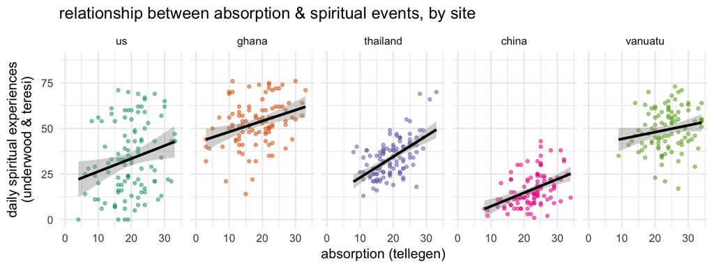